# Forecasting rcp45 data

Ishara Wijayaratne

2024-01-04

The below code is applied to a 31x31 (row x col) square raster with 240 layers.

### 1.0 Install the Required Libraries

```r
library(terra)
library(dplyr) #facilitates the use of %>% operator
library(tidyverse)
library(ggplot2)
```

### 2.0 Import NetCDF(nc) or tif files.

In this case, NetCDF files are used and are imported as follows.

Precipitation:

```r
pr_rcp45 <- terra::rast("C:/Users/i.wijayarathne/OneDrive - CGIAR/Desktop/Project1/Project1/Test_data/rcm_outputs/rcp45/pr/2030/ENSEMBLE_MEAN/pr_EUR-11_ENSEMBLE-MEAN_historical_rcp45_2020-2039.nc")
pr_rcp45
```

```
class       : SpatRaster
dimensions  : 31, 31, 240  (nrow, ncol, nlyr)
resolution  : 0.1, 0.1  (x, y)
extent      : -10.05, -6.95, 28.95, 32.05  (xmin, xmax, ymin, ymax)
coord. ref. : lon/lat WGS 84 (CRS84) (OGC:CRS84)
source      : pr_EUR-11_ENSEMBLE-MEAN_historical_rcp45_2020-2039.nc:pr
varname     : pr (Precipitation)
names       :   pr_1,   pr_2,   pr_3,   pr_4,   pr_5,   pr_6, ...
unit        : mm_day, mm_day, mm_day, mm_day, mm_day, mm_day, ...
time (days) : 2020-01-16 to 2039-12-16
```

Visualizing the first layer of precipitation.

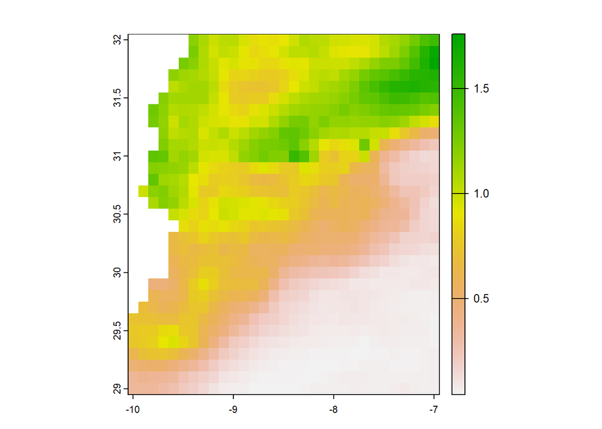

```r
p1 <- pr_rcp45[[1]]
plot(p1)
```

```r
#summary(values(pr_rcp45)) - can obtain a summary of all the values in the layers
#values(pr_rcp45) - This is an array
```

Maximum Temperature:

```r
tasmax_rcp45 <- terra::rast("C:/Users/i.wijayarathne/OneDrive - CGIAR/Desktop/Project1/Project1/Test_data/rcm_outputs/rcp45/tasmax/2030/ENSEMBLE_MEAN/tasmax_EUR-11_ENSEMBLE-MEAN_historical_rcp45_2020-2039.nc")
tasmax_rcp45
```

```
class       : SpatRaster
dimensions  : 31, 31, 240  (nrow, ncol, nlyr)
resolution  : 0.1, 0.1  (x, y)
extent      : -10.05, -6.95, 28.95, 32.05  (xmin, xmax, ymin, ymax)
coord. ref. : lon/lat WGS 84 (CRS84) (OGC:CRS84)
source      : tasmax_EUR-11_ENSEMBLE-MEAN_historical_rcp45_2020-2039.nc:tasmax
varname     : tasmax (Daily Maximum Near-Surface Air Temperature)
names       : tasmax_1, tasmax_2, tasmax_3, tasmax_4, tasmax_5, tasmax_6, ...
unit        :     degC,     degC,     degC,     degC,     degC,     degC, ...
time (days) : 2020-01-16 to 2039-12-16
```

Minimum Temperature:

```r
tasmin_rcp45 <- terra::rast("C:/Users/i.wijayarathne/OneDrive - CGIAR/Desktop/Project1/Project1/Test_data/rcm_outputs/rcp45/tasmin/2030/ENSEMBLE_MEAN/tasmin_EUR-11_ENSEMBLE-MEAN_historical_rcp45_2020-2039.nc")
tasmin_rcp45
```

```
class       : SpatRaster
dimensions  : 31, 31, 240  (nrow, ncol, nlyr)
resolution  : 0.1, 0.1  (x, y)
extent      : -10.05, -6.95, 28.95, 32.05  (xmin, xmax, ymin, ymax)
coord. ref. : lon/lat WGS 84 (CRS84) (OGC:CRS84)
source      : tasmin_EUR-11_ENSEMBLE-MEAN_historical_rcp45_2020-2039.nc:tasmin
varname     : tasmin (Daily Minimum Near-Surface Air Temperature)
names       : tasmin_1, tasmin_2, tasmin_3, tasmin_4, tasmin_5, tasmin_6, ...
unit        :     degC,     degC,     degC,     degC,     degC,     degC, ...
time (days) : 2020-01-16 to 2039-12-16
```

Average Temperature:

```r
tasavg_rcp45 <- (tasmax_rcp45 + tasmin_rcp45)/2
tasavg_rcp45
```

```
class       : SpatRaster
dimensions  : 31, 31, 240  (nrow, ncol, nlyr)
resolution  : 0.1, 0.1  (x, y)
extent      : -10.05, -6.95, 28.95, 32.05  (xmin, xmax, ymin, ymax)
coord. ref. : lon/lat WGS 84 (CRS84) (OGC:CRS84)
source(s)   : memory
varname     : tasmax (Daily Maximum Near-Surface Air Temperature)
names       :   tasmax_1,  tasmax_2, tasmax_3,  tasmax_4, tasmax_5, tasmax_6, ...
min values  :  0.9544532,  3.216361,  4.65861,  7.914564, 10.64054, 14.78823, ...
max values  : 14.6330037, 18.407739, 21.42843, 25.587259, 28.72469, 32.79246, ...
time (days) : 2020-01-16 to 2039-12-16
```

Suppose you have tif files, the code to import tif files using the terra package is as follows:

*`Pr1 <- terra::rast("file_location/xyz1.tif")`* *`Max_temp <- terra::rast("file_location/xyz2.tif")`* *`Min_temp <- terra::rast("file_location/xyz3.tif")`*

### 3.0 Julian day calculation

Note that all the above SpatRasters have the same “time” component. Let’s extract this component.

```r
time <- time(tasmin_rcp45) # Type = "Date"
#class(time)
head(time,50) #View the first 50 values of the variable "time"
```

```
 [1] "2020-01-16" "2020-02-15" "2020-03-16" "2020-04-16" "2020-05-16"
 [6] "2020-06-16" "2020-07-16" "2020-08-16" "2020-09-16" "2020-10-16"
[11] "2020-11-16" "2020-12-16" "2021-01-16" "2021-02-15" "2021-03-16"
[16] "2021-04-16" "2021-05-16" "2021-06-16" "2021-07-16" "2021-08-16"
[21] "2021-09-16" "2021-10-16" "2021-11-16" "2021-12-16" "2022-01-16"
[26] "2022-02-15" "2022-03-16" "2022-04-16" "2022-05-16" "2022-06-16"
[31] "2022-07-16" "2022-08-16" "2022-09-16" "2022-10-16" "2022-11-16"
[36] "2022-12-16" "2023-01-16" "2023-02-15" "2023-03-16" "2023-04-16"
[41] "2023-05-16" "2023-06-16" "2023-07-16" "2023-08-16" "2023-09-16"
[46] "2023-10-16" "2023-11-16" "2023-12-16" "2024-01-16" "2024-02-15"
```

Calculating the Julian days as follows:

Julian days simply is the number of days since the end of the previous year. Ex: The Julian days for “2020-01-16”, is the number of days to this date from “2019-12-31”, which is 16 days.

```r
# Calculate the number of days since the start of the current year:
prior_year <- year(time)-1
head(prior_year,10) #View the first 10 values of the variable "prior_year"
```

```
 [1] 2019 2019 2019 2019 2019 2019 2019 2019 2019 2019
```

```r
tail(prior_year,10) #View the last 10 values of the variable "prior_year"
```

```
 [1] 2038 2038 2038 2038 2038 2038 2038 2038 2038 2038
```

```r
end.of.prior_year <- as.Date(paste0(prior_year, "-12-31"))
head(end.of.prior_year,10)
```

```
 [1] "2019-12-31" "2019-12-31" "2019-12-31" "2019-12-31" "2019-12-31"
 [6] "2019-12-31" "2019-12-31" "2019-12-31" "2019-12-31" "2019-12-31"
```

```r
tail(end.of.prior_year,10) #View the last 10 values of the variable "end.of.prior_year"
```

```
 [1] "2038-12-31" "2038-12-31" "2038-12-31" "2038-12-31" "2038-12-31"
 [6] "2038-12-31" "2038-12-31" "2038-12-31" "2038-12-31" "2038-12-31"
```

```r
Julian_days <- time - end.of.prior_year #In the variable "Julian days" leap years are accounted for
Julian_days <- as.vector(Julian_days) #Convert into a vector
Julian_days
```

```
  [1]  16  46  76 107 137 168 198 229 260 290 321 351  16  46  75 106 136 167
 [19] 197 228 259 289 320 350  16  46  75 106 136 167 197 228 259 289 320 350
 [37]  16  46  75 106 136 167 197 228 259 289 320 350  16  46  76 107 137 168
 [55] 198 229 260 290 321 351  16  46  75 106 136 167 197 228 259 289 320 350
 [73]  16  46  75 106 136 167 197 228 259 289 320 350  16  46  75 106 136 167
 [91] 197 228 259 289 320 350  16  46  76 107 137 168 198 229 260 290 321 351
[109]  16  46  75 106 136 167 197 228 259 289 320 350  16  46  75 106 136 167
[127] 197 228 259 289 320 350  16  46  75 106 136 167 197 228 259 289 320 350
[145]  16  46  76 107 137 168 198 229 260 290 321 351  16  46  75 106 136 167
[163] 197 228 259 289 320 350  16  46  75 106 136 167 197 228 259 289 320 350
[181]  16  46  75 106 136 167 197 228 259 289 320 350  16  46  76 107 137 168
[199] 198 229 260 290 321 351  16  46  75 106 136 167 197 228 259 289 320 350
[217]  16  46  75 106 136 167 197 228 259 289 320 350  16  46  75 106 136 167
[235] 197 228 259 289 320 350
```

Suppose you are using tif files, you may have to initially create a vector in the above manner.

### 4.0 Extract the relevant Longitude and Latitude as vectors.

```r
# Get the cell numbers
cell_no <- 1:ncell(tasmin_rcp45) #row-wise fashion
head(cell_no,15)
```

```
 [1]  1  2  3  4  5  6  7  8  9 10 11 12 13 14 15
```

```r
tail(cell_no,5) #31*31 = 961
```

```
[1] 957 958 959 960 961
```

```r
# Get the latitudes corresponding to the cell numbers
lat <- yFromCell(tasmin_rcp45, cell_no)
lat <- as.vector(lat)
# Print first 50 values
head(lat,50)
```

```
 [1] 32.0 32.0 32.0 32.0 32.0 32.0 32.0 32.0 32.0 32.0 32.0 32.0 32.0 32.0 32.0
[16] 32.0 32.0 32.0 32.0 32.0 32.0 32.0 32.0 32.0 32.0 32.0 32.0 32.0 32.0 32.0
[31] 32.0 31.9 31.9 31.9 31.9 31.9 31.9 31.9 31.9 31.9 31.9 31.9 31.9 31.9 31.9
[46] 31.9 31.9 31.9 31.9 31.9
```

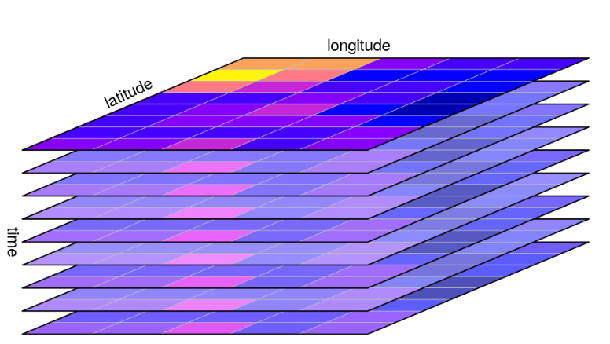

```r
# Get the longitudes corresponding to the cell numbers
lon <- xFromCell(tasmin_rcp45, cell_no)
lon <- as.vector(lon)
# Print first 50 values:
head(lon,50) #Repetition of the 31 values can be observed
```

```
 [1] -10.0  -9.9  -9.8  -9.7  -9.6  -9.5  -9.4  -9.3  -9.2  -9.1  -9.0  -8.9
[13]  -8.8  -8.7  -8.6  -8.5  -8.4  -8.3  -8.2  -8.1  -8.0  -7.9  -7.8  -7.7
[25]  -7.6  -7.5  -7.4  -7.3  -7.2  -7.1  -7.0 -10.0  -9.9  -9.8  -9.7  -9.6
[37]  -9.5  -9.4  -9.3  -9.2  -9.1  -9.0  -8.9  -8.8  -8.7  -8.6  -8.5  -8.4
[49]  -8.3  -8.2
```

### 5.0 Calculating Modified Hargreaves reference ET

#### 5.1 Step 1: Supporting Equations

$$Gsc = 0.082 \\
jd = Julian \ days \\
\text{Lat}_{\text{rad}} = (pi/180) * Lat \\
dr = 1+0.033*COS(2*(pi/365)*jd) \\
d = 0.409*SIN(2*(pi/365)*jd-1.39) \\
ws = ACOS(-TAN(\text{Lat}_{\text{rad}})*TAN(d)) \\$$

```r
Gsc <- 0.082 ; Gsc
```

```
[1] 0.082
```

```r
jd <- Julian_days ; head(jd,5) #vector
```

```
[1]  16  46  76 107 137
```

Creating a Spatraster for Lat_rad.

```r
Lat_rad <- (pi/180)*lat


# Get dimensions of tasmin_rcp45
dims <- c(ncol(tasmin_rcp45), nrow(tasmin_rcp45),  1)

# Create an empty SpatRaster with the same dimensions as tasmin_rcp45
Lat_spatraster <- rast(
  ncol = dims[1],
  nrow = dims[2],
  nlyr = dims[3],
  xmin = ext(tasmin_rcp45)[1],
  xmax = ext(tasmin_rcp45)[2],
  ymin = ext(tasmin_rcp45)[3],
  ymax = ext(tasmin_rcp45)[4],
  crs = crs(tasmin_rcp45)
)

# Fill the empty SpatRaster with elements from Lat_rad
values(Lat_spatraster) <- Lat_rad
print(Lat_spatraster)
```

```
class       : SpatRaster
dimensions  : 31, 31, 1  (nrow, ncol, nlyr)
resolution  : 0.1, 0.1  (x, y)
extent      : -10.05, -6.95, 28.95, 32.05  (xmin, xmax, ymin, ymax)
coord. ref. : lon/lat WGS 84 (CRS84) (OGC:CRS84)
source(s)   : memory
name        :     lyr.1
min value   : 0.5061455
max value   : 0.5585054
```

```r
#Lat_spatraster[1, 1, 1] - can obtain the row, col, layer value.
```

Create dr vector.

```r
dr <- 1 + 0.033*cos(2*(pi/365)*jd) ; head(dr,5) #vector
```

```
[1] 1.0317562 1.0231834 1.0085639 0.9911621 0.9766153
```

Create d vector.

```r
d <- 0.409*sin( (2*(pi/365)*jd) - 1.39 ) ; head(d,5) #vector
```

```
[1] -0.36716855 -0.23031271 -0.03338642  0.17860771  0.33699544
```

```r
dims <- c(ncol(tasmin_rcp45), nrow(tasmin_rcp45),  length(d))

# Create an empty SpatRaster with the same extent and resolution
ws_spatraster <- rast(
  ncol = dims[1],
  nrow = dims[2],
  nlyr = dims[3],
  xmin = ext(tasmin_rcp45)[1],
  xmax = ext(tasmin_rcp45)[2],
  ymin = ext(tasmin_rcp45)[3],
  ymax = ext(tasmin_rcp45)[4],
  crs = crs(tasmin_rcp45)
)


# Loop through each value in vector d
for (i in seq_along(d)) {
  WS <- acos(-tan(Lat_spatraster) * tan(d[i]))

  # Assign the result to the corresponding layer
  ws_spatraster[[i]] <- WS

  # Set layer names based on i
  names(ws_spatraster)[i] <- paste("lyr", i, sep = ".")
}

# Print the created SpatRaster
print(ws_spatraster)
```

```
class       : SpatRaster
dimensions  : 31, 31, 240  (nrow, ncol, nlyr)
resolution  : 0.1, 0.1  (x, y)
extent      : -10.05, -6.95, 28.95, 32.05  (xmin, xmax, ymin, ymax)
coord. ref. : lon/lat WGS 84 (CRS84) (OGC:CRS84)
source(s)   : memory
names       :    lyr.1,    lyr.2,    lyr.3,    lyr.4,    lyr.5,    lyr.6, ...
min values  : 1.328090, 1.423752, 1.549925, 1.671034, 1.766246, 1.812775, ...
max values  : 1.355955, 1.440457, 1.552282, 1.683846, 1.791513, 1.844321, ...
```

#### 5.2 Step 2: Equations for Radiation(Ra_MJ):

$$Ra_{\text{MJ}} = \frac{24 \times 60}{\pi} \cdot Gsc \cdot dr \cdot
\left(ws \cdot \sin(\text{Lat}_{\text{rad}}) \cdot \sin(d) +
\cos(\text{Lat}_{\text{rad}}) \cdot \cos(d) \cdot \sin(ws)\right)$$

For step 1 a vector(1D) is obtained.
$$Step\space 1 = \frac{24 \times 60}{\pi} \cdot Gsc \cdot dr$$

```r
step1 <- ((24*60)/pi)*Gsc*dr
```

From step 2 an array(3D) is obtained.
$$Step \space 2 = ws \cdot \sin(d) \cdot \sin(\text{Lat}_{\text{rad}})
\\\
\space \space = k1 \cdot \sin(\text{Lat}_{\text{rad}})$$

```r
dims <- c(ncol(tasmin_rcp45), nrow(tasmin_rcp45),  length(d))

# Create an empty SpatRaster with the same extent and resolution
k1_spatraster <- rast(
  ncol = dims[1],
  nrow = dims[2],
  nlyr = dims[3],
  xmin = ext(tasmin_rcp45)[1],
  xmax = ext(tasmin_rcp45)[2],
  ymin = ext(tasmin_rcp45)[3],
  ymax = ext(tasmin_rcp45)[4],
  crs = crs(tasmin_rcp45)
)

for (i in seq_along(d)) {
  # Multiply the i-th layer of k1_spatraster by the i-th element of sin(d)
  k1_spatraster[[i]] <- ws_spatraster[[i]] * sin(d[i])

  # Set layer names based on i
  names(k1_spatraster)[i] <- paste("lyr", i, sep = ".")
}

# Print the created SpatRaster k1_spatraster
print(k1_spatraster)
```

```
class       : SpatRaster
dimensions  : 31, 31, 240  (nrow, ncol, nlyr)
resolution  : 0.1, 0.1  (x, y)
extent      : -10.05, -6.95, 28.95, 32.05  (xmin, xmax, ymin, ymax)
coord. ref. : lon/lat WGS 84 (CRS84) (OGC:CRS84)
source(s)   : memory
names       :      lyr.1,      lyr.2,       lyr.3,     lyr.4,     lyr.5,     lyr.6, ...
min values  : -0.4867528, -0.3288304, -0.05181551, 0.2968753, 0.5840146, 0.7193160, ...
max values  : -0.4767500, -0.3250169, -0.05173683, 0.2991513, 0.5923693, 0.7318336, ...
```

```r
dims <- c(ncol(tasmin_rcp45), nrow(tasmin_rcp45),  length(d))

# Create an empty SpatRaster with the same extent and resolution
step2_spatraster <- rast(
  ncol = dims[1],
  nrow = dims[2],
  nlyr = dims[3],
  xmin = ext(tasmin_rcp45)[1],
  xmax = ext(tasmin_rcp45)[2],
  ymin = ext(tasmin_rcp45)[3],
  ymax = ext(tasmin_rcp45)[4],
  crs = crs(tasmin_rcp45)
)

# Step 2: Loop through each layer of k1_spatraster and multiply by sin(Lat_spatraster)
for (k in seq_len(nlyr(k1_spatraster))) {
  k1_layer <- k1_spatraster[[k]]
  Lat_layer <- Lat_spatraster[[1]]

  # Multiply each element by sin(Lat_spatraster)
  step2_layer <- k1_layer * sin(Lat_layer)

  # Assign the result to the corresponding layer
  step2_spatraster[[k]] <- step2_layer

  # Set layer names based on k
  names(step2_spatraster)[k] <- paste("lyr", k, sep = ".")
}

# Print the created SpatRaster step2_spatraster
print(step2_spatraster)
```

```
class       : SpatRaster
dimensions  : 31, 31, 240  (nrow, ncol, nlyr)
resolution  : 0.1, 0.1  (x, y)
extent      : -10.05, -6.95, 28.95, 32.05  (xmin, xmax, ymin, ymax)
coord. ref. : lon/lat WGS 84 (CRS84) (OGC:CRS84)
source(s)   : memory
names       :      lyr.1,      lyr.2,       lyr.3,     lyr.4,     lyr.5,     lyr.6, ...
min values  : -0.2526390, -0.1722327, -0.02741634, 0.1439280, 0.2831359, 0.3487313, ...
max values  : -0.2359824, -0.1594201, -0.02512066, 0.1585261, 0.3139079, 0.3878127, ...
```

For step 3 an array(3D) is obtained.
$$Step \space 3 = \sin(ws) \cdot \cos(d) \cdot
\cos(\text{Lat}_{\text{rad}}) \\
= k2 \cdot \cos(\text{Lat}_{\text{rad}})$$

```r
dims <- c(ncol(tasmin_rcp45), nrow(tasmin_rcp45),  length(d))

# Create an empty SpatRaster with the same extent and resolution
k2_spatraster <- rast(
  ncol = dims[1],
  nrow = dims[2],
  nlyr = dims[3],
  xmin = ext(tasmin_rcp45)[1],
  xmax = ext(tasmin_rcp45)[2],
  ymin = ext(tasmin_rcp45)[3],
  ymax = ext(tasmin_rcp45)[4],
  crs = crs(tasmin_rcp45)
)

for (i in seq_along(d)) {
  # Multiply the i-th layer of k2_spatraster by the i-th element of cos(d)
  k2_spatraster[[i]] <- sin(ws_spatraster[[i]]) * cos(d[i])

  # Set layer names based on i
  names(k2_spatraster)[i] <- paste("lyr", i, sep = ".")
}

# Print the created k2_spatraster
print(k2_spatraster)
```

```
class       : SpatRaster
dimensions  : 31, 31, 240  (nrow, ncol, nlyr)
resolution  : 0.1, 0.1  (x, y)
extent      : -10.05, -6.95, 28.95, 32.05  (xmin, xmax, ymin, ymax)
coord. ref. : lon/lat WGS 84 (CRS84) (OGC:CRS84)
source(s)   : memory
names       :     lyr.1,     lyr.2,     lyr.3,     lyr.4,     lyr.5,     lyr.6, ...
min values  : 0.9059921, 0.9630884, 0.9992250, 0.9778103, 0.9208577, 0.8837801, ...
max values  : 0.9118901, 0.9653369, 0.9992714, 0.9791522, 0.9257838, 0.8911610, ...
```

```r
dims <- c(ncol(tasmin_rcp45), nrow(tasmin_rcp45),  length(d))

# Create an empty SpatRaster with the same extent and resolution
step3_spatraster <- rast(
  ncol = dims[1],
  nrow = dims[2],
  nlyr = dims[3],
  xmin = ext(tasmin_rcp45)[1],
  xmax = ext(tasmin_rcp45)[2],
  ymin = ext(tasmin_rcp45)[3],
  ymax = ext(tasmin_rcp45)[4],
  crs = crs(tasmin_rcp45)
)

# Step 2: Loop through each layer of k2_spatraster and multiply by cos(Lat_spatraster)
for (k in seq_len(nlyr(k2_spatraster))) {
  k2_layer <- k2_spatraster[[k]]
  Lat_layer <- Lat_spatraster[[1]]  # Lat_spatraster is a single layer SpatRaster

  # Multiply each element by cos(Lat_spatraster)
  step3_layer <- k2_layer * cos(Lat_layer)

  # Assign the result to the corresponding layer
  step3_spatraster[[k]] <- step3_layer

  # Set layer names based on k
  names(step3_spatraster)[k] <- paste("lyr", k, sep = ".")
}

# Print the created step3_spatraster
print(step3_spatraster)
```

```
class       : SpatRaster
dimensions  : 31, 31, 240  (nrow, ncol, nlyr)
resolution  : 0.1, 0.1  (x, y)
extent      : -10.05, -6.95, 28.95, 32.05  (xmin, xmax, ymin, ymax)
coord. ref. : lon/lat WGS 84 (CRS84) (OGC:CRS84)
source(s)   : memory
names       :     lyr.1,     lyr.2,     lyr.3,     lyr.4,     lyr.5,     lyr.6, ...
min values  : 0.7683249, 0.8167453, 0.8473909, 0.8292301, 0.7809316, 0.7494881, ...
max values  : 0.7975570, 0.8443027, 0.8739825, 0.8563858, 0.8097087, 0.7794270, ...
```

Calculating Ra_MJ a 3D array:

$$Ra_{\text{MJ}} = Step\space 1 \cdot (Step\space 2 + Step\space 3) \\
= Step\space 1 \cdot \text{int_step}$$

```r
int_step <- (step2_spatraster + step3_spatraster)
Ra_MJ <- step1*int_step
print(Ra_MJ)
```

```
class       : SpatRaster
dimensions  : 31, 31, 240  (nrow, ncol, nlyr)
resolution  : 0.1, 0.1  (x, y)
extent      : -10.05, -6.95, 28.95, 32.05  (xmin, xmax, ymin, ymax)
coord. ref. : lon/lat WGS 84 (CRS84) (OGC:CRS84)
source(s)   : memory
names       :    lyr.1,    lyr.2,    lyr.3,    lyr.4,    lyr.5,    lyr.6, ...
min values  : 19.99810, 24.78628, 31.08352, 36.79772, 40.11515, 41.04706, ...
max values  : 21.77765, 26.33880, 32.17858, 37.26554, 40.18838, 41.37970, ...
```

#### 5.3 Step 3: Equations for Radiation(Ra):

$$Ra = Ra_{\text{MJ}} \cdot 0.408 \\
Ra_{\text{MJ}} = \text{Radiation in Mega-joules per square meter per
day} \, [MJ \, m^{-2} \, d^{-1}]$$

Calculating Ra a 3D array:

```r
Ra <- Ra_MJ*0.408
print(Ra)
```

```
class       : SpatRaster
dimensions  : 31, 31, 240  (nrow, ncol, nlyr)
resolution  : 0.1, 0.1  (x, y)
extent      : -10.05, -6.95, 28.95, 32.05  (xmin, xmax, ymin, ymax)
coord. ref. : lon/lat WGS 84 (CRS84) (OGC:CRS84)
source(s)   : memory
names       :    lyr.1,    lyr.2,    lyr.3,    lyr.4,    lyr.5,    lyr.6, ...
min values  : 8.159226, 10.11280, 12.68208, 15.01347, 16.36698, 16.74720, ...
max values  : 8.885281, 10.74623, 13.12886, 15.20434, 16.39686, 16.88292, ...
```

#### 5.4 Step 4: Equation for Evapotranspiration:

Calculate modified Hargreaves Mod_ET_0 a 3D array:

$${\text Mod\_ET_0} = 0.0013 \cdot Ra \cdot (T_{\text{mean}} + 17.0) \cdot
((T_{\text{max}} - T_{\text{min}}) - 0.0123 \cdot P)^{0.76} \\
= Ra \cdot \text{temp_pr}$$

```r
temp_pr <- 0.0013*(tasavg_rcp45 + 17)*(((tasmax_rcp45 - tasmin_rcp45) - (0.0123*pr_rcp45))^0.76)
Mod_ET_0 <- Ra * temp_pr
print(Mod_ET_0)
```

```
class       : SpatRaster
dimensions  : 31, 31, 240  (nrow, ncol, nlyr)
resolution  : 0.1, 0.1  (x, y)
extent      : -10.05, -6.95, 28.95, 32.05  (xmin, xmax, ymin, ymax)
coord. ref. : lon/lat WGS 84 (CRS84) (OGC:CRS84)
source(s)   : memory
names       :    lyr.1,    lyr.2,    lyr.3,    lyr.4,    lyr.5,    lyr.6, ...
min values  : 1.206182, 1.625023, 1.901470, 2.383800, 2.457041, 2.295997, ...
max values  : 2.507672, 3.688176, 5.186307, 7.217216, 8.542882, 9.719148, ...
```

Calculate Hargreaves ET_0 a 3D array:
$$ET_0 = 0.0023 \cdot (T_{\text{mean}} + 17.8) \cdot (T_{\text{max}} -
T_{\text{min}})^{0.50}\cdot Ra \\$$

```r
ET_0 <- 0.0023*(tasavg_rcp45 + 17.8)*((tasmax_rcp45 - tasmin_rcp45)^0.50)*Ra
print(ET_0)
```

```
class       : SpatRaster
dimensions  : 31, 31, 240  (nrow, ncol, nlyr)
resolution  : 0.1, 0.1  (x, y)
extent      : -10.05, -6.95, 28.95, 32.05  (xmin, xmax, ymin, ymax)
coord. ref. : lon/lat WGS 84 (CRS84) (OGC:CRS84)
source(s)   : memory
varname     : tasmax (Daily Maximum Near-Surface Air Temperature)
names       : tasmax_1, tasmax_2, tasmax_3, tasmax_4, tasmax_5, tasmax_6, ...
min values  : 1.196874, 1.739509, 2.267525, 2.812637, 2.969295, 2.889077, ...
max values  : 2.321411, 3.346454, 4.583749, 6.211316, 7.271827, 8.210354, ...
time (days) : 2020-01-16 to 2039-12-16
```

### 6.0 Calculating AET.

$$AET = P \cdot [1 + PET/P - (1 + (PET/P)^{\omega})^{1 / \omega}] \\
\omega = 1.8$$

```r
AET = pr_rcp45*(1 + (Mod_ET_0/pr_rcp45) - (1 + (Mod_ET_0/pr_rcp45)^1.8)^{1/1.8})
print(AET)
```

```
class       : SpatRaster
dimensions  : 31, 31, 240  (nrow, ncol, nlyr)
resolution  : 0.1, 0.1  (x, y)
extent      : -10.05, -6.95, 28.95, 32.05  (xmin, xmax, ymin, ymax)
coord. ref. : lon/lat WGS 84 (CRS84) (OGC:CRS84)
source(s)   : memory
varname     : pr (Precipitation)
names       :       pr_1,      pr_2,       pr_3,        pr_4,       pr_5,       pr_6, ...
min values  : 0.04224798, 0.0644887, 0.01270434, 0.002331169, 0.00974337, 0.03176247, ...
max values  : 0.95821201, 0.8921841, 1.56229257, 1.154202948, 0.90683220, 2.19038450, ...
time (days) : 2020-01-16 to 2039-12-16
```

### 7.0 The already calculated and available ET_0 data.

```r
PET_rcp45 <- terra::rast("C:/Users/i.wijayarathne/OneDrive - CGIAR/Desktop/Project1/Project1/Test_data/PET/cordex_era/rcp45/2030/eto_EUR-11_ENSEMBLE-MEAN_rcp45_2020-2039_MONMEAN.nc")
PET_rcp45
```

```
class       : SpatRaster
dimensions  : 31, 41, 240  (nrow, ncol, nlyr)
resolution  : 0.1, 0.1  (x, y)
extent      : -11.05, -6.95, 28.95, 32.05  (xmin, xmax, ymin, ymax)
coord. ref. : lon/lat WGS 84 (CRS84) (OGC:CRS84)
source      : eto_EUR-11_ENSEMBLE-MEAN_rcp45_2020-2039_MONMEAN.nc:ET_pot
varname     : ET_pot (potential_evapotranspiration)
names       : ET_pot_1, ET_pot_2, ET_pot_3, ET_pot_4, ET_pot_5, ET_pot_6, ...
unit        :   mm_day,   mm_day,   mm_day,   mm_day,   mm_day,   mm_day, ...
time (days) : 2020-01-16 to 2039-12-16
```